# Модель Раша

```r
wd <- getwd()
assignments <- fread("unzip -cq ../data/assignments.zip")  %>% group_by(course_name) %>%
 mutate(course_item_type_desc = factor(course_item_type_desc), vis_before_attempt_tw_b = ifelse(vis_before_attempt_tw==0, 0, 1), vis_b = ifelse(vis_tw==0, 0, 1), vis_before_attempt_tw_b = factor(vis_before_attempt_tw_b))
```

## 1. Об отчете

### Исследовательские вопросы

1. Как связаны вероятность выполнения задания и посещение форума во время выполнения задания?
2. Как связаны число попыток и посещение форума во время выполнения задания?

## Описание базы данных

- **assignments** - база данных, с данными на уровне студентов

## Описание переменных

Важные:

- **attempts** - Попытки за задание. Сколько попыток этот студент сделал при решении этого задания;
- **vis_tw** - Посещения форума. Сколько раз этот студент посещал форум во время прохождения этого задания. Важно: считается посещение форума за все время пока студент взаимодействует с заданием;
- **vis_before_attempt_tw** - Предварительное посещение форума - количество посещенных страниц форума с момента, когда студент начал решать задание и до момента когда студент совершил первую попытку;
- **vis_before_attempt_tw_b** - Посещал студент форум или нет с момента, когда начал решать задание и до момента когда совершил первую попытку. В анализе используется эта переменная потому что с предыдущей модель не сходится;
- **assessment_status** - Статус выполнения задания: 1 - удалось решить, 0 - не удалось решить.
- **first_attempt** - Статус выполнения задания после первой попытки: 1 - удалось решить с первой попытки, 0 - не удалось решить с первой попытки.
- **vis_b** - заходил студент на форум во время взаимодействия с заданием или нет?

Менее важные:

- **assessment_id** - токен задания;
- **hse_user_id** - токен студента;
- **course_item_type_desc** - тип задания;

#### О модели Раша

Модель Раша - популярная психометрическая модель, предполагающая нелинейную связь между оценками студента за задание и его знаниями. Мы будем знания определять с помощью попыток за задания и посещений форума.

#### Распределение переменной assessment_status

```r
table(assignments$assessment_status)
```

```
##
##      1
## 544446
```

```r
table(assignments$first_attempt)
```

```
##
##      0      1
## 161879 382567
```

```r
table(assignments$course_item_type_desc, assignments$vis_b)
```

```
##
##                    0      1
##   programming  29586  25859
##   quiz        450005  38996
```

```r
table(assignments$course_item_type_desc, assignments$vis_before_attempt_tw_b)
```

```
##
##                    0      1
##   programming  35656  19789
##   quiz        471454  17547
```

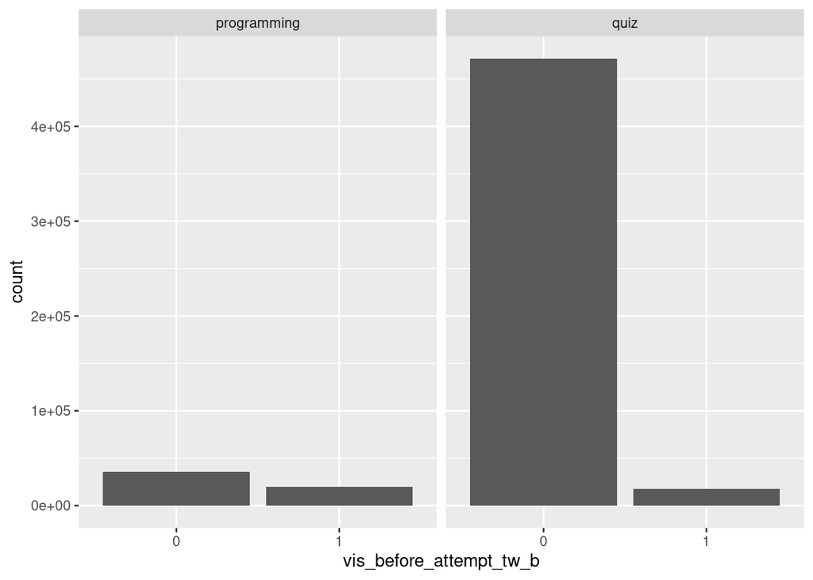

```r
assignments %>%  ggplot(aes(x = vis_before_attempt_tw_b)) + geom_histogram(stat="count")+ facet_wrap(~course_item_type_desc)
```

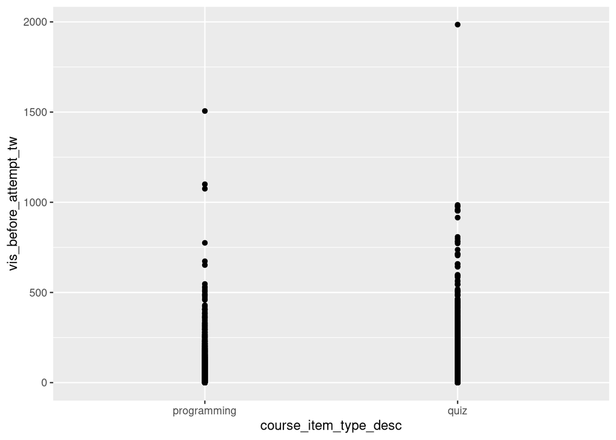

```r
assignments %>%  ggplot(aes(x = course_item_type_desc, y = vis_before_attempt_tw)) + geom_point()
```

```r
assignments %>% group_by(x = course_item_type_desc) %>% summarize(mean_vis = mean(vis_before_attempt_tw))
```

```
## # A tibble: 2 x 2
##   x           mean_vis
##   <fct>          <dbl>
## 1 programming     8.86
## 2 quiz            1.04
```

```r
assignments %>% group_by(x = course_item_type_desc, vis_before_attempt_tw_b) %>% summarize(probability_to_pass = sum(first_attempt)/ n())
```

```
## # A tibble: 4 x 3
## # Groups:   x [2]
##   x           vis_before_attempt_tw_b probability_to_pass
##   <fct>       <fct>                                 <dbl>
## 1 programming 0                                     0.546
## 2 programming 1                                     0.488
## 3 quiz        0                                     0.728
## 4 quiz        1                                     0.580
```

#### Распределение переменной attempts

```r
summary(assignments$attempts)
```

```
##    Min. 1st Qu.  Median    Mean 3rd Qu.    Max.
##   1.000   1.000   1.000   2.202   3.000 431.000
```

```r
summary(assignments$vis_before_attempt_tw)
```

```
##    Min. 1st Qu.  Median    Mean 3rd Qu.    Max.
##    0.00    0.00    0.00    1.84    0.00 1985.00
```

## 2. Вероятность выполнить задание с первой попытки

#### Дисперсия вероятности выполнить задание с первой попытки по студентам и заданиям

```r
mr00 <- glm(data = assignments, factor(first_attempt) ~ 1, family = "binomial")
summary(mr00)
```

```
##
## Call:
## glm(formula = factor(first_attempt) ~ 1, family = "binomial",
##     data = assignments)
##
## Deviance Residuals:
##     Min       1Q   Median       3Q      Max
## -1.5575  -1.5575   0.8401   0.8401   0.8401
##
## Coefficients:
##             Estimate Std. Error z value Pr(>|z|)
## (Intercept) 0.860055   0.002965   290.1   <2e-16 ***
## ---
## Signif. codes:  0 '***' 0.001 '**' 0.01 '*' 0.05 '.' 0.1 ' ' 1
##
## (Dispersion parameter for binomial family taken to be 1)
##
##     Null deviance: 662681  on 544445  degrees of freedom
## Residual deviance: 662681  on 544445  degrees of freedom
## AIC: 662683
##
## Number of Fisher Scoring iterations: 4
```

```r
mr0 <- glmer(data = assignments, factor(first_attempt) ~ 1 + (1|hse_user_id) + (1|course_item_name), family = "binomial")
summary(mr0)
```

```
## Generalized linear mixed model fit by maximum likelihood (Laplace
##   Approximation) [glmerMod]
##  Family: binomial  ( logit )
## Formula: factor(first_attempt) ~ 1 + (1 | hse_user_id) + (1 | course_item_name)
##    Data: assignments
##
##       AIC       BIC    logLik  deviance  df.resid
##  566587.1  566620.8 -283290.6  566581.1    544443
##
## Scaled residuals:
##      Min       1Q   Median       3Q      Max
## -11.1590  -0.7175   0.3636   0.5861  14.3924
##
## Random effects:
##  Groups           Name        Variance Std.Dev.
##  hse_user_id      (Intercept) 0.7315   0.8553
##  course_item_name (Intercept) 1.2692   1.1266
## Number of obs: 544446, groups:  hse_user_id, 34735; course_item_name, 454
##
## Fixed effects:
##             Estimate Std. Error z value Pr(>|z|)
## (Intercept)  0.97170    0.05215   18.63   <2e-16 ***
## ---
## Signif. codes:  0 '***' 0.001 '**' 0.01 '*' 0.05 '.' 0.1 ' ' 1
```

```r
sd_proficieny <- data.frame(VarCorr(mr0))[5][1, 1]
sd_difficulty <- data.frame(VarCorr(mr0))[5][2, 1]
coef <- summary(mr0)$coef[1] # intercept of m0
```

```
## Отклонение по студентам (подготовленности) - 0.86.
```

```
## Отклонение по заданиям (сложности) - 1.13.
```

```r
c_proficieny <- c(round(invlogit(coef - sd_proficieny), digits = 2), round(invlogit(coef + sd_proficieny), digits = 2))
c_difficulty <- c(round(invlogit(coef - sd_proficieny - sd_difficulty), digits = 2), round(invlogit(coef - sd_proficieny + sd_difficulty), digits = 2))
```

```
## Вероятность  с первой попытки выполнить среднее задание средним студентом - 0.73, beta - 0.97.
```

```
## Эта вероятность будет колебаться между 0.53 и 0.86  с одним стандартным отклонением квалификации студента ниже и выше.
```

```
## Эта вероятность будет колебаться между 0.27 и 0.78  с одним стандартным отклонением сложности задания ниже и выше.
```

```r
ll1 <- logLik(mr00)*-2
ll2 <- logLik(mr0)*-2
chi <- ll1[1] - ll2[1]
chi
```

```
## [1] 96100.27
```

```r
df <- 3-1
df
```

```
## [1] 2
```

```r
# the results are significant if qchisq greater than chi
qchisq(p=.0001, df=df, lower.tail=FALSE)
```

```
## [1] 18.42068
```

## 3. Влияние предварительного посещения форума на вероятность решить задание с первой попытки

```r
mr1 <- glmer(data = assignments, factor(first_attempt) ~ 1 + vis_before_attempt_tw_b  + (1|hse_user_id) + (1|course_item_name), family = "binomial")
summary(mr1)
```

```
## Generalized linear mixed model fit by maximum likelihood (Laplace
##   Approximation) [glmerMod]
##  Family: binomial  ( logit )
## Formula:
## factor(first_attempt) ~ 1 + vis_before_attempt_tw_b + (1 | hse_user_id) +
##     (1 | course_item_name)
##    Data: assignments
##
##       AIC       BIC    logLik  deviance  df.resid
##  566428.3  566473.1 -283210.1  566420.3    544442
##
## Scaled residuals:
##      Min       1Q   Median       3Q      Max
## -11.0984  -0.7139   0.3642   0.5863  14.0001
##
## Random effects:
##  Groups           Name        Variance Std.Dev.
##  hse_user_id      (Intercept) 0.7244   0.8511
##  course_item_name (Intercept) 1.2493   1.1177
## Number of obs: 544446, groups:  hse_user_id, 34735; course_item_name, 454
##
## Fixed effects:
##                          Estimate Std. Error z value Pr(>|z|)
## (Intercept)               0.98815    0.05202   19.00   <2e-16 ***
## vis_before_attempt_tw_b1 -0.19171    0.01493  -12.84   <2e-16 ***
## ---
## Signif. codes:  0 '***' 0.001 '**' 0.01 '*' 0.05 '.' 0.1 ' ' 1
##
## Correlation of Fixed Effects:
##             (Intr)
## vs_bfr_t__1 -0.032
```

```r
mrr1 <- summary(mr1)
```

```r
tab_model(mr1)
```

|  | factor(first attempt) |  |  |
| --- | --- | --- | --- |
| Predictors | Odds Ratios | CI | p |
| (Intercept) | 2.69 | 2.43 – 2.97 | **<0.001** |
| vis_before_attempt_tw_b [1] | 0.83 | 0.80 – 0.85 | **<0.001** |
| Random Effects |  |  |  |
| σ<sup>2</sup> | 3.29 |  |  |
| τ<sub>00</sub> <sub>hse_user_id</sub> | 0.72 |  |  |
| τ<sub>00</sub> <sub>course_item_name</sub> | 1.25 |  |  |
| ICC | 0.37 |  |  |
| N <sub>hse_user_id</sub> | 34735 |  |  |
| N <sub>course_item_name</sub> | 454 |  |  |
| Observations | 544446 |  |  |
| Marginal R<sup>2</sup> / Conditional R<sup>2</sup> | 0.000 / 0.375 |  |  |

```
## Вероятность, что студент выполнит задание с первой попытки, если до первой попытки он не посещал форум, равна 0.73.
```

```
## Вероятность, что студент выполнит задание с первой попытки, если студент посетил форум хотя бы 1 раз до совершения попытки - 0.69
```

#### Визуализация

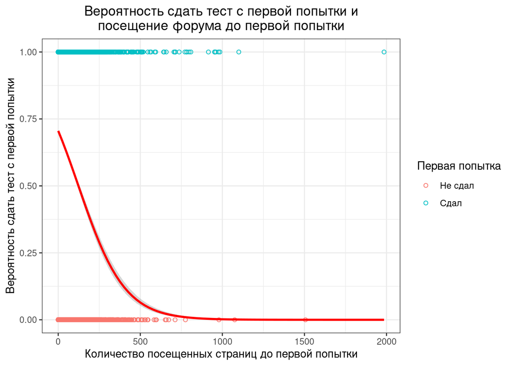

```r
assignments  %>%   ggplot(aes(x = vis_before_attempt_tw, y = first_attempt)) +
  geom_point(aes(color = as.factor(first_attempt)), shape = 1)   +
# построит регрессионную линию, сигмоиду
  geom_smooth(method = "glm", color = "red", method.args=list(family="binomial")) +
# напечатает легенду, название графика и осей
  ggtitle("Вероятность сдать тест с первой попытки и\nпосещение форума до первой попытки") +
  scale_color_discrete(labels=c("Не сдал", "Сдал")) +
  labs(x = "Количество посещенных страниц до первой попытки", y = "Вероятность сдать тест с первой попытки", color = "Первая попытка") +
# задает цветовую тему графика
  theme_bw() +
# выравнивает название по центру
  theme(plot.title = element_text(hjust = 0.5))
```

```r
anova(mr0, mr1)
```

```
## Data: assignments
## Models:
## mr0: factor(first_attempt) ~ 1 + (1 | hse_user_id) + (1 | course_item_name)
## mr1: factor(first_attempt) ~ 1 + vis_before_attempt_tw_b + (1 | hse_user_id) +
## mr1:     (1 | course_item_name)
##     npar    AIC    BIC  logLik deviance  Chisq Df Pr(>Chisq)
## mr0    3 566587 566621 -283291   566581
## mr1    4 566428 566473 -283210   566420 160.88  1  < 2.2e-16 ***
## ---
## Signif. codes:  0 '***' 0.001 '**' 0.01 '*' 0.05 '.' 0.1 ' ' 1
```

## 4. Влияние типа задания на вероятность решить задание с первой попытки

```r
mr1 <- glmer(data = assignments, factor(first_attempt) ~ 1 + course_item_type_desc  + (1|hse_user_id) + (1|course_item_name), family = "binomial")
summary(mr1)
```

```
## Generalized linear mixed model fit by maximum likelihood (Laplace
##   Approximation) [glmerMod]
##  Family: binomial  ( logit )
## Formula:
## factor(first_attempt) ~ 1 + course_item_type_desc + (1 | hse_user_id) +
##     (1 | course_item_name)
##    Data: assignments
##
##       AIC       BIC    logLik  deviance  df.resid
##  566572.1  566616.9 -283282.1  566564.1    544442
##
## Scaled residuals:
##      Min       1Q   Median       3Q      Max
## -11.1567  -0.7166   0.3637   0.5863  14.3804
##
## Random effects:
##  Groups           Name        Variance Std.Dev.
##  hse_user_id      (Intercept) 0.7313   0.8552
##  course_item_name (Intercept) 1.2328   1.1103
## Number of obs: 544446, groups:  hse_user_id, 34735; course_item_name, 454
##
## Fixed effects:
##                           Estimate Std. Error z value Pr(>|z|)
## (Intercept)                0.83763    0.05886   14.23  < 2e-16 ***
## course_item_type_descquiz  0.15113    0.03607    4.19 2.79e-05 ***
## ---
## Signif. codes:  0 '***' 0.001 '**' 0.01 '*' 0.05 '.' 0.1 ' ' 1
##
## Correlation of Fixed Effects:
##             (Intr)
## crs_tm_typ_ -0.503
```

```r
mrr1 <- summary(mr1)
```

```r
tab_model(mr1)
```

|  | factor(first attempt) |  |  |
| --- | --- | --- | --- |
| Predictors | Odds Ratios | CI | p |
| (Intercept) | 2.31 | 2.06 – 2.59 | **<0.001** |
| course_item_type_desc [quiz] | 1.16 | 1.08 – 1.25 | **<0.001** |
| Random Effects |  |  |  |
| σ<sup>2</sup> | 3.29 |  |  |
| τ<sub>00</sub> <sub>hse_user_id</sub> | 0.73 |  |  |
| τ<sub>00</sub> <sub>course_item_name</sub> | 1.23 |  |  |
| ICC | 0.37 |  |  |
| N <sub>hse_user_id</sub> | 34735 |  |  |
| N <sub>course_item_name</sub> | 454 |  |  |
| Observations | 544446 |  |  |
| Marginal R<sup>2</sup> / Conditional R<sup>2</sup> | 0.000 / 0.374 |  |  |

```
## Вероятность, что студент выполнит задание с первой попытки, если это курс по программированию равна 0.70.
```

```
## Вероятность, что студент выполнит задание с первой попытки, если это курс не по программированию - 0.73
```

## 5. Влияние предварительного посещения форума и типа курса на вероятность решить задание с первой попытки с 2 случ эффектами

### course_item_name

```r
mr3 <- glmer(data = assignments, factor(first_attempt) ~ 1 + vis_before_attempt_tw_b*course_item_type_desc + (1|hse_user_id) + (1|course_item_name), family = "binomial")
summary(mr3)
```

```
## Generalized linear mixed model fit by maximum likelihood (Laplace
##   Approximation) [glmerMod]
##  Family: binomial  ( logit )
## Formula:
## factor(first_attempt) ~ 1 + vis_before_attempt_tw_b * course_item_type_desc +
##     (1 | hse_user_id) + (1 | course_item_name)
##    Data: assignments
##
##       AIC       BIC    logLik  deviance  df.resid
##  566405.1  566472.3 -283196.5  566393.1    544440
##
## Scaled residuals:
##      Min       1Q   Median       3Q      Max
## -11.1016  -0.7133   0.3642   0.5863  13.8726
##
## Random effects:
##  Groups           Name        Variance Std.Dev.
##  hse_user_id      (Intercept) 0.7244   0.8511
##  course_item_name (Intercept) 1.2323   1.1101
## Number of obs: 544446, groups:  hse_user_id, 34735; course_item_name, 454
##
## Fixed effects:
##                                                    Estimate Std. Error z value
## (Intercept)                                         0.93749    0.05886  15.927
## vis_before_attempt_tw_b1                           -0.26701    0.02247 -11.880
## course_item_type_descquiz                           0.05720    0.03593   1.592
## vis_before_attempt_tw_b1:course_item_type_descquiz  0.13950    0.02931   4.759
##                                                    Pr(>|z|)
## (Intercept)                                         < 2e-16 ***
## vis_before_attempt_tw_b1                            < 2e-16 ***
## course_item_type_descquiz                             0.111
## vis_before_attempt_tw_b1:course_item_type_descquiz 1.95e-06 ***
## ---
## Signif. codes:  0 '***' 0.001 '**' 0.01 '*' 0.05 '.' 0.1 ' ' 1
##
## Correlation of Fixed Effects:
##             (Intr) vs____1 crs___
## vs_bfr_t__1 -0.118
## crs_tm_typ_ -0.504  0.215
## vs____1:___  0.092 -0.742  -0.184
```

```r
mrr3 <- summary(mr3)
```

```
## Вероятность, что студент выполнит задание с первой попытки, если во время взаимодействия с заданием он не посещал форум и это задание по программированию, равна 0.7186.
```

```
## Вероятность, что студент выполнит задание с первой попытки, если во время взаимодействия с заданием он посещал форум и это задание по программированию, равна 0.6616.
```

```
## Вероятность, что студент выполнит задание с первой попытки,  если во время взаимодействия с заданием он не посещал форум и это тест, равна 0.7300.
```

[output not shown]

### course_name

```r
mr3 <- glmer(data = assignments, factor(first_attempt) ~ 1 + vis_before_attempt_tw_b*course_item_type_desc + (1|hse_user_id) + (1|course_name), family = "binomial")
summary(mr3)
```

```
## Generalized linear mixed model fit by maximum likelihood (Laplace
##   Approximation) [glmerMod]
##  Family: binomial  ( logit )
## Formula:
## factor(first_attempt) ~ 1 + vis_before_attempt_tw_b * course_item_type_desc +
##     (1 | hse_user_id) + (1 | course_name)
##    Data: assignments
##
##       AIC       BIC    logLik  deviance  df.resid
##  605443.9  605511.2 -302716.0  605431.9    544440
##
## Scaled residuals:
##     Min      1Q  Median      3Q     Max
## -5.9365 -0.9056  0.4135  0.6565  3.8589
##
## Random effects:
##  Groups      Name        Variance Std.Dev.
##  hse_user_id (Intercept) 0.5893   0.7677
##  course_name (Intercept) 0.3900   0.6245
## Number of obs: 544446, groups:  hse_user_id, 34735; course_name, 49
##
## Fixed effects:
##                                                    Estimate Std. Error z value
## (Intercept)                                         0.56156    0.06619   8.485
## vis_before_attempt_tw_b1                           -0.06690    0.01935  -3.458
## course_item_type_descquiz                           0.39029    0.01424  27.399
## vis_before_attempt_tw_b1:course_item_type_descquiz -0.20701    0.02626  -7.883
##                                                    Pr(>|z|)
## (Intercept)                                         < 2e-16 ***
## vis_before_attempt_tw_b1                           0.000545 ***
## course_item_type_descquiz                           < 2e-16 ***
## vis_before_attempt_tw_b1:course_item_type_descquiz  3.2e-15 ***
## ---
## Signif. codes:  0 '***' 0.001 '**' 0.01 '*' 0.05 '.' 0.1 ' ' 1
##
## Correlation of Fixed Effects:
##             (Intr) vs____1 crs___
## vs_bfr_t__1 -0.055
## crs_tm_typ_ -0.107  0.490
## vs____1:___  0.038 -0.707  -0.401
```

```r
mrr3 <- summary(mr3)
```

```
## Вероятность, что студент выполнит задание с первой попытки, если во время взаимодействия с заданием он не посещал форум и это задание по программированию, равна 0.6368.
```

```
## Вероятность, что студент выполнит задание с первой попытки, если во время взаимодействия с заданием он посещал форум и это задание по программированию, равна 0.6212.
```

```
## Вероятность, что студент выполнит задание с первой попытки,  если во время взаимодействия с заданием он не посещал форум и это тест, равна 0.7215.
```

[output not shown]

```r
tab <- assignments %>% group_by(vis_before_attempt_tw_b, course_item_type_desc) %>% summarise(n = n(), prob = sum(first_attempt) / n())
tab
```

```
## # A tibble: 4 x 4
## # Groups:   vis_before_attempt_tw_b [2]
##   vis_before_attempt_tw_b course_item_type_desc      n  prob
##   <fct>                   <fct>                  <int> <dbl>
## 1 0                       programming            35656 0.546
## 2 0                       quiz                  471454 0.728
## 3 1                       programming            19789 0.488
## 4 1                       quiz                   17547 0.580
```

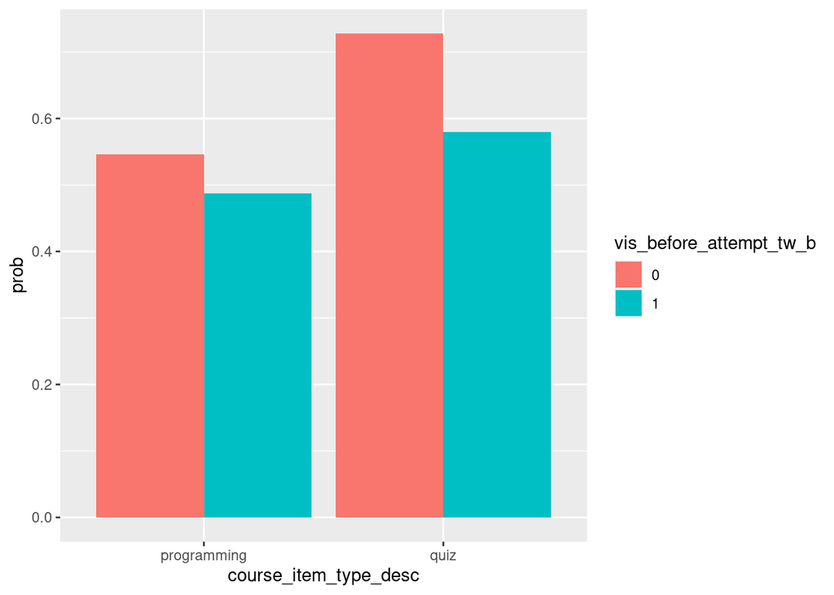

```r
tab %>%  ggplot(aes(y = prob, fill = vis_before_attempt_tw_b, x = course_item_type_desc)) + geom_bar(stat='identity', position = 'dodge')
```

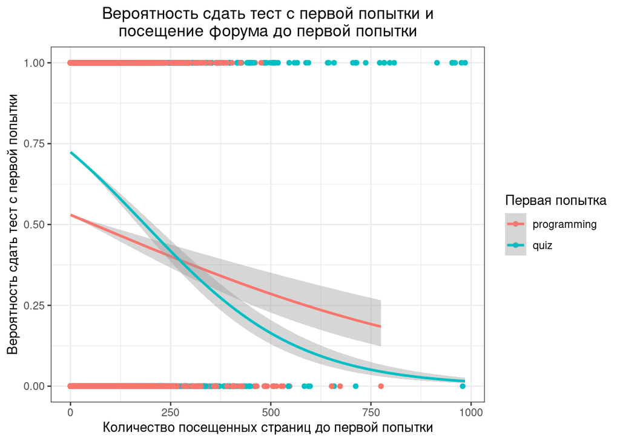

```r
assignments  %>% filter(vis_before_attempt_tw < 1000) %>%   ggplot(aes(x = vis_before_attempt_tw, y = first_attempt, color = course_item_type_desc)) +
  geom_point()   +
# построит регрессионную линию, сигмоиду
  geom_smooth(method = "glm", method.args=list(family="binomial")) +
# напечатает легенду, название графика и осей
  ggtitle("Вероятность сдать тест с первой попытки и\nпосещение форума до первой попытки") +
  labs(x = "Количество посещенных страниц до первой попытки", y = "Вероятность сдать тест с первой попытки", color = "Первая попытка") +
# задает цветовую тему графика
  theme_bw() +
# выравнивает название по центру
  theme(plot.title = element_text(hjust = 0.5))
```

## 6. Без группировки

```r
mr4 <- glm(data = assignments, factor(first_attempt) ~ 1 + vis_before_attempt_tw_b*course_item_type_desc, family = "binomial")
summary(mr4)
```

```
##
## Call:
## glm(formula = factor(first_attempt) ~ 1 + vis_before_attempt_tw_b *
##     course_item_type_desc, family = "binomial", data = assignments)
##
## Deviance Residuals:
##     Min       1Q   Median       3Q      Max
## -1.6139  -1.2568   0.7966   0.7966   1.1985
##
## Coefficients:
##                                                    Estimate Std. Error z value
## (Intercept)                                         0.18462    0.01064   17.36
## vis_before_attempt_tw_b1                           -0.23405    0.01776  -13.18
## course_item_type_descquiz                           0.80048    0.01113   71.93
## vis_before_attempt_tw_b1:course_item_type_descquiz -0.42904    0.02366  -18.13
##                                                    Pr(>|z|)
## (Intercept)                                          <2e-16 ***
## vis_before_attempt_tw_b1                             <2e-16 ***
## course_item_type_descquiz                            <2e-16 ***
## vis_before_attempt_tw_b1:course_item_type_descquiz   <2e-16 ***
## ---
## Signif. codes:  0 '***' 0.001 '**' 0.01 '*' 0.05 '.' 0.1 ' ' 1
##
## (Dispersion parameter for binomial family taken to be 1)
##
##     Null deviance: 662681  on 544445  degrees of freedom
## Residual deviance: 652141  on 544442  degrees of freedom
## AIC: 652149
##
## Number of Fisher Scoring iterations: 4
```

```r
mrr4 <- summary(mr4)
```

```
## Вероятность, что студент выполнит задание с первой попытки, если во время взаимодействия с заданием он не посещал форум и это задание по программированию, равна 0.5460.
```

```
## Вероятность, что студент выполнит задание с первой попытки, если во время взаимодействия с заданием он посещал форум и это задание по программированию, равна 0.4876.
```

```
## Вероятность, что студент выполнит задание с первой попытки,  если во время взаимодействия с заданием он не посещал форум и это тест, равна 0.7281.
```

[output not shown]

```r
assignments %>% group_by(x = course_item_type_desc, vis_before_attempt_tw_b) %>% summarize(probability_to_pass = sum(first_attempt)/ n())
```

```
## # A tibble: 4 x 3
## # Groups:   x [2]
##   x           vis_before_attempt_tw_b probability_to_pass
##   <fct>       <fct>                                 <dbl>
## 1 programming 0                                     0.546
## 2 programming 1                                     0.488
## 3 quiz        0                                     0.728
## 4 quiz        1                                     0.580
```

## 7. Есть ли эффект научения?

Вероятность решить задание с первой попытки может повышаться из-за эффекта научения. Студент может с каждой новой неделей лучше решать задачи. Поэтому возьмем один курс и посмотрим по каждой неделе: есть ли разница между вероятностью решить задание с первой попытки если заходил на форум или не заходил на форум (переменная **vis_before_attempt_tw_b**).

```r
course_branch_items <- fread("../data/vvedenie-mashinnoe-obuchenie/course_branch_items.csv") %>% dplyr::select(course_lesson_id, course_item_id, course_branch_item_name, is_graded)
course_branch_modules <- fread("../data/vvedenie-mashinnoe-obuchenie/course_branch_modules.csv") %>% dplyr::select(course_module_id, course_branch_module_order, course_branch_module_name)
course_branch_lessons <- fread("../data/vvedenie-mashinnoe-obuchenie/course_branch_lessons.csv") %>% dplyr::select(-course_branch_id)

vmo <- left_join(course_branch_lessons, course_branch_items) %>% left_join(., course_branch_modules)

total <- assignments %>%  filter(course_name == "vvedenie-mashinnoe-obuchenie") %>% dplyr::select(course_item_id,  course_item_name, hse_user_id, vis_before_attempt_tw_b, first_attempt) %>%  left_join(., vmo, by="course_item_id") %>% mutate(first_attempt = recode(first_attempt, `1` = "pass", `0` = "fail"), vis_before_attempt_tw_b = recode(vis_before_attempt_tw_b, `1` = "visites", `0` = "not_visited"))
```

Я выбрал курс "Введение в машинное обучение и сравнил вероятность решить задание первой попытки у тех, кто предварительно заходил на форум или не заходил, *отдельно для пяти недель*.

```r
i = 1
while (i < 6) {
  a <- total %>% filter(course_branch_module_order == i)
  tab <- table(a$first_attempt, a$vis_before_attempt_tw_b)
  chisq <- chisq.test(tab)
  cat(sprintf("\nweek %d", i))
  print(tab)
  print(chisq)
  i = i + 1
}
```

```
##
## week 1
##        not_visited visites
##   fail        2378     244
##   pass        3499     505
##
##  Pearson's Chi-squared test with Yates' continuity correction
##
## data:  tab
## X-squared = 16.949, df = 1, p-value = 3.839e-05
##
##
## week 2
##        not_visited visites
##   fail        2712     636
##   pass        4364     786
##
##  Pearson's Chi-squared test with Yates' continuity correction
##
## data:  tab
## X-squared = 20.039, df = 1, p-value = 7.586e-06
##
##
## week 3
##        not_visited visites
##   fail        2665     381
##   pass        3353     351
##
##  Pearson's Chi-squared test with Yates' continuity correction
##
## data:  tab
## X-squared = 15.58, df = 1, p-value = 7.907e-05
##
##
## week 4
##        not_visited visites
##   fail        7018    1807
##   pass        7461    1643
##
##  Pearson's Chi-squared test with Yates' continuity correction
##
## data:  tab
## X-squared = 16.857, df = 1, p-value = 4.031e-05
##
##
## week 5
##        not_visited visites
##   fail        2337     612
##   pass        3431     378
##
##  Pearson's Chi-squared test with Yates' continuity correction
##
## data:  tab
## X-squared = 155.02, df = 1, p-value < 2.2e-16
```